# Understanding Financial Markets by analysing Yahoo Finance with R

Oscar Toro

2020-10-21

Yahoo finance offers a good way of obtaining data from the financial market. It contains information from multiple markets worldwide, offering a summary, statistics, historical data, financials, stock analysis, and more useful information. Ideally, we would like to see how a sector in any market is performing, and we could do this by using the data provided by Yahoo (responsibly).

In order to do this, we will scrape the Yahoo finance website. Please note that you should be confident with basic R and have some background in scraping; however, this last part can be quickly learnt (as I did while doing this task). A final note, I believe Python is a better language for webscrapping, and financial data should be obtanied via APIs rather than scarping websites; however, APIs are usually behind paywalls and could be quite expensive.

Finally, there are packages which might do most of the activities we are doing here (Quantmod, Quandl).

We will be obtaining Australian Stock Market infomation for this example.

```r
library(tidyverse)
library(kableExtra)
```

### ASX

The first step is to obtain a list of the tickers we will need to scrape from yahoo. You could compile this list manually, or download it from the ASX page as I did in the code below. Please note that this list might have tickers which are not used, and it should be cleaned.

```r
stock_list <- readr::read_csv("https://asx.api.markitdigital.com/asx-research/1.0/companies/directory/file")
```

A quick review on this data shows us that it includes the code, company name, listing date and industry group.

```r
stock_list %>% head() %>% kable() %>% kable_styling()
```

| ASX code | Company name | Listing date | GICs industry group |
| --- | --- | --- | --- |
| 14D | 1414 DEGREES LIMITED | 2018-09-12 | Capital Goods |
| 1AD | ADALTA LIMITED | 2016-08-22 | Pharmaceuticals, Biotechnology & Life Sciences |
| 1AG | ALTERRA LIMITED | 2008-05-16 | Commercial & Professional Services |
| 1ST | 1ST GROUP LIMITED | 2015-06-09 | Health Care Equipment & Services |
| 2BE | TUBI LIMITED | 2019-06-14 | Energy |
| 360 | LIFE360 INC. | 2019-05-10 | Software & Services |

This table tells us that there are 1981 different tickers, in the following industries:

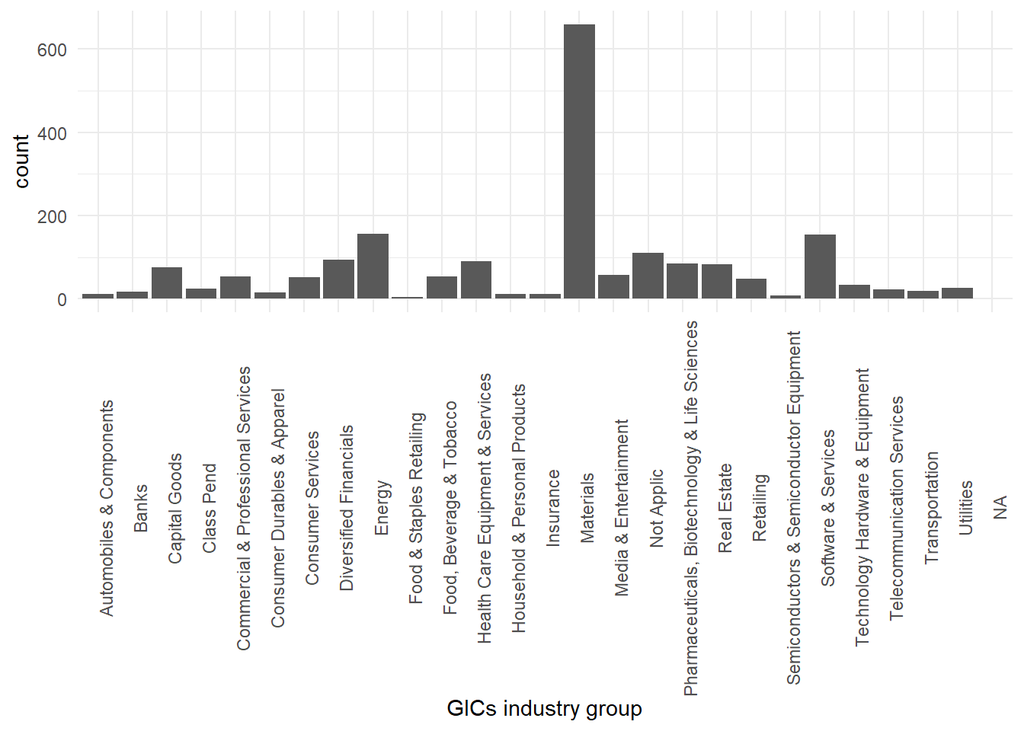

```r
stock_list %>%
  ggplot(aes(x=`GICs industry group`)) +
  geom_bar() +
  theme_minimal() +
  theme(axis.text.x = element_text(angle=90))
```